# Final project for BIOF439

Jacob Roth

5/22/2019

## Define jsr.theme4

```r
jsr.theme4 <- theme_bw() %+replace%
  theme(
    plot.title = element_text(family = NULL, face = NULL, colour = "black", size = 13,
                              hjust = 0.5, vjust = 2, angle = NULL, lineheight = NULL),
    plot.subtitle = element_text(family = NULL, face = NULL, colour = "slategray4", size = 9,
                                 hjust = 0.5, vjust = 1.5, angle = NULL, lineheight = NULL,
                                 color = NULL),
    panel.grid.major  = element_line(color = "azure3", size = 0.5),
    panel.grid.minor  = element_line(color = "azure2", size = 0.5),
    panel.background = element_rect(fill = "azure"),
    plot.margin = margin(1, 1, 1, 1, "cm"),
    panel.border = element_rect(color = "darkslategray4", fill = NA),
    axis.line = element_line(color = "darkslategray4", size = 0.5),
    axis.ticks = element_line(color = "darkslategray4"),
    axis.text = element_text(color = "black", size = 8),
    axis.title.x = element_blank()
  )
```

## Review of the cell lines that I have screened

In this project, I’ve been working with an external collaborator (a pharmaceutical company) to explore cytotoxic combination synergies between a few investigational compounds that they are developing as oncology therapies. At NCATS, we are interested in the mechanism of action of these compounds and developing the field’s knowledge on these interactions across multiple cell lines. Our collaborator is interested in working to identify biomarkers and/or indications that may be sensitive to combination therapies for a few of their compounds in early phase I trials.

Utilizing only 180 uL of 10 mM DMSO stock solutions, we prepared over 320 1,536-well assay plates, screened 160 cell lines, and created nearly half a million data points. Of 160 unique cell lines we screened, data from 153 cell lines met assay performance cut-offs. Science-enabling robots are awesome.

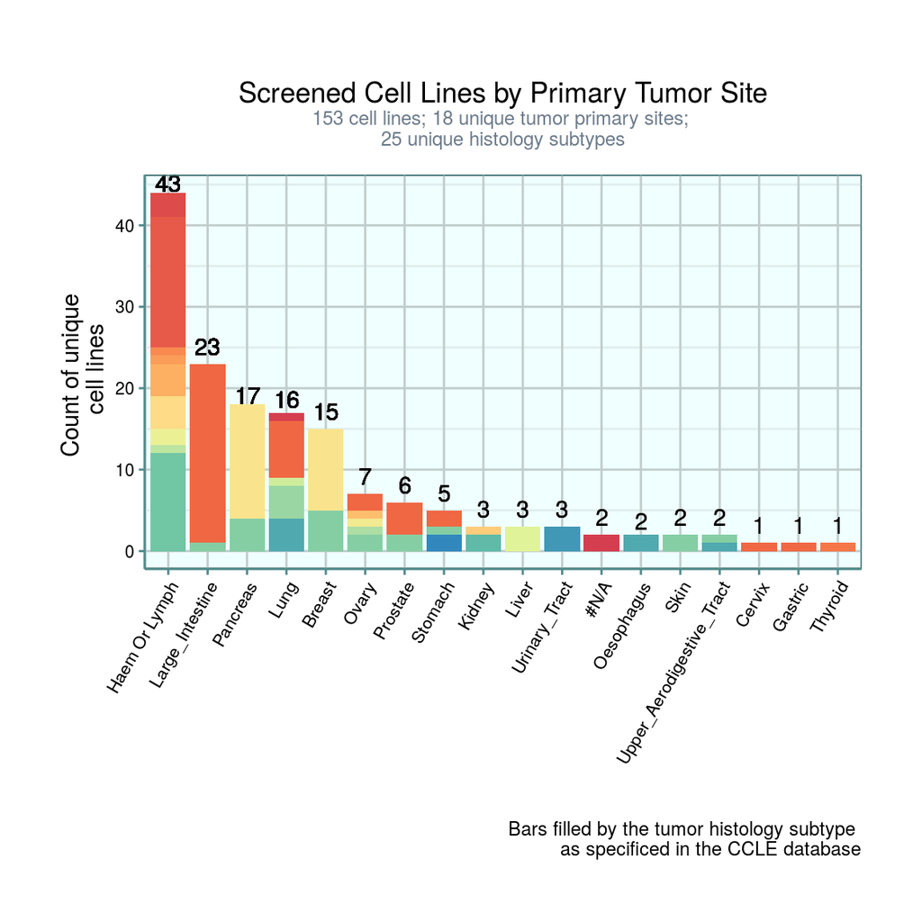

## Exploring drug combination synergies; Compounds X and Y vs Compounds A-F

This figure compares the combination synergy scores (as calculated by the Bliss synergy metric) of compound A versus compounds X or Y when screened against 153 unique cancer cell lines. This visualization depicts the data as a boxplot, comparing the responses between compound X and Y, parsed by the site primary of the tumor of origin. Future work will integrate this data with genomic data and mutational status of the relevant genes of interest.

(Data is blinded as agreed upon in a CDA with our external collaborator)

For a meeting with our collaborators last week, I replicated this figure for all combinations A-F and further explored the same type of display with the Histology Subtype data for each primary site for the most interesting combinations of X or Y with A-F.

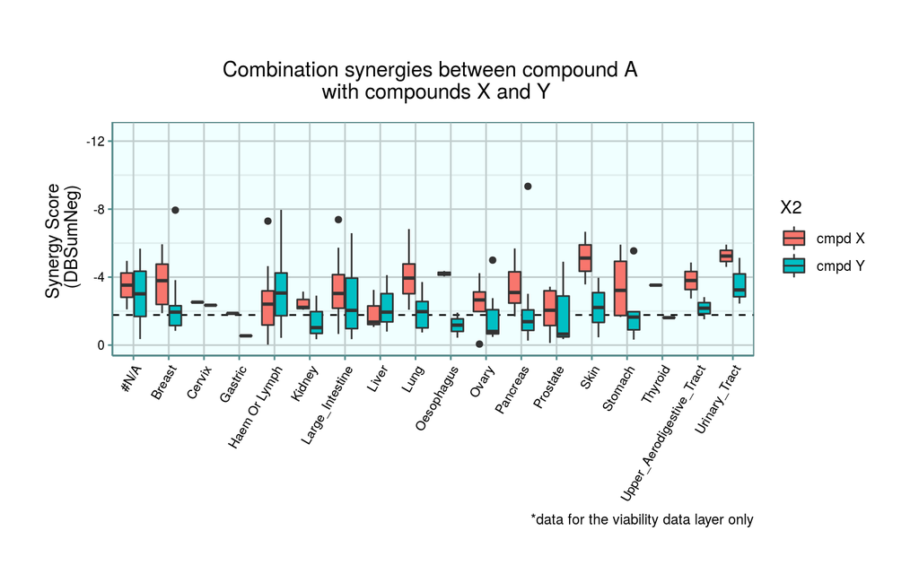